# Entrega_final (2)

```python
#Librerías necesarias para el análisis
import pandas as pd
import matplotlib.pyplot as plt
import seaborn as sns
```

```python
student_math = pd.read_csv('/content/student-mat.csv')
student_por = pd.read_csv('/content/student-por.csv')
```

```python
# Verificar que ambos dataset tengan las mimas columnas
mat_columns = set(student_math.columns)
por_columns = set(student_por.columns)

columns_match = mat_columns == por_columns

# Consolidar columnas
if columns_match:
    data = pd.concat([student_math, student_por], ignore_index=True)
else:
    data = None

columns_match, data.head()
```

```
(True,
   school sex  age address famsize Pstatus  Medu  Fedu     Mjob      Fjob  ...  \
 0     GP   F   18       U     GT3       A     4     4  at_home   teacher  ...
 1     GP   F   17       U     GT3       T     1     1  at_home     other  ...
 2     GP   F   15       U     LE3       T     1     1  at_home     other  ...
 3     GP   F   15       U     GT3       T     4     2   health  services  ...
 4     GP   F   16       U     GT3       T     3     3    other     other  ...

   famrel freetime  goout  Dalc  Walc health absences  G1  G2  G3
 0      4        3      4     1     1      3        6   5   6   6
 1      5        3      3     1     1      3        4   5   5   6
 2      4        3      2     2     3      3       10   7   8  10
 3      3        2      2     1     1      5        2  15  14  15
 4      4        3      2     1     2      5        4   6  10  10

 [5 rows x 33 columns])
```

**ANÁLISIS EXPLORATORIO**

```python
# Obtener información general del dataset
info_dataset = data.info()
# Verificar valores nulos
nulos = data.isnull().sum()
# Generar estadísticas descriptivas
Est_desc = data.describe

()# Resultados del análisis exploratorio
info_dataset, nulos, Est_desc
```

```
<class 'pandas.core.frame.DataFrame'>
RangeIndex: 1044 entries, 0 to 1043
Data columns (total 33 columns):
 #   Column      Non-Null Count  Dtype
---  ------      --------------  -----
 0   school      1044 non-null   object
 1   sex         1044 non-null   object
 2   age         1044 non-null   int64
 3   address     1044 non-null   object
 4   famsize     1044 non-null   object
 5   Pstatus     1044 non-null   object
 6   Medu        1044 non-null   int64
 7   Fedu        1044 non-null   int64
 8   Mjob        1044 non-null   object
 9   Fjob        1044 non-null   object
```

[output cut: 25 more lines]

```
(None,
 school        0
 sex           0
 age           0
 address       0
 famsize       0
 Pstatus       0
 Medu          0
 Fedu          0
 Mjob          0
 Fjob          0
 reason        0
 guardian      0
 traveltime    0
 studytime     0
 failures      0
 schoolsup     0
 famsup        0
 paid          0
 activities    0
 nursery       0
 higher        0
 internet      0
 romantic      0
 famrel        0
 freetime      0
 goout         0
 Dalc          0
 Walc          0
 health        0
 absences      0
 G1            0
 G2            0
 G3            0
 dtype: int64,
 <bound method NDFrame.describe of      school sex  age address famsize Pstatus  Medu  Fedu      Mjob      Fjob  \
 0        GP   F   18       U     GT3       A     4     4   at_home   teacher
 1        GP   F   17       U     GT3       T     1     1   at_home     other
 2        GP   F   15       U     LE3       T     1     1   at_home     other
 3        GP   F   15       U     GT3       T     4     2    health  services
 4        GP   F   16       U     GT3       T     3     3     other     other
 ...     ...  ..  ...     ...     ...     ...   ...   ...       ...       ...
 1039     MS   F   19       R     GT3       T     2     3  services     other
 1040     MS   F   18       U     LE3       T     3     1   teacher  services
 1041     MS   F   18       U     GT3       T     1     1     other     other
 1042     MS   M   17       U     LE3       T     3     1  services  services
 1043     MS   M   18       R     LE3       T     3     2  services     other

       ... famrel freetime  goout  Dalc  Walc health absences  G1  G2  G3
 0     ...      4        3      4     1     1      3        6   5   6   6
 1     ...      5        3      3     1     1      3        4   5   5   6
 2     ...      4        3      2     2     3      3       10   7   8  10
 3     ...      3        2      2     1     1      5        2  15  14  15
 4     ...      4        3      2     1     2      5        4   6  10  10
 ...   ...    ...      ...    ...   ...   ...    ...      ...  ..  ..  ..
 1039  ...      5        4      2     1     2      5        4  10  11  10
 1040  ...      4        3      4     1     1      1        4  15  15  16
 1041  ...      1        1      1     1     1      5        6  11  12   9
 1042  ...      2        4      5     3     4      2        6  10  10  10
 1043  ...      4        4      1     3     4      5        4  10  11  11

 [1044 rows x 33 columns]>)
```

**Conclusiones del análisis exploratorio:**

- El dataset completo contiene 1044 registros y 33 columnas
- No hay presencia de valores nulos.
- Las columnas contienen datos de tipo categórico y numérico
- La edad de los alumnos varía entre los 15 y 22 años con una media de 16,7 años.
- el 75% de los estudiantes tienen entre 0 y 6 días de ausencias.
- las notas (G1, G2 y H3) en un rango de 0 a 20 presentan una media cercana a 11 suiriendo un rendimiento académico medio.
- el consumo de alcohol en días de la semana (Dalc) tiene una media de 1.49 mientras que los fines de semana (Walc) es mayor con una media de 2.28

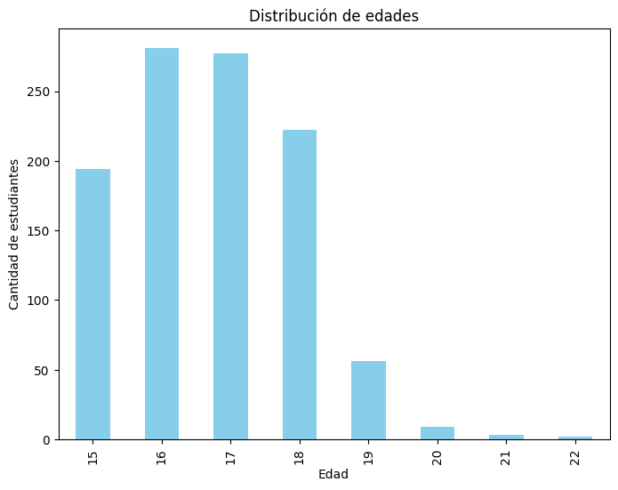

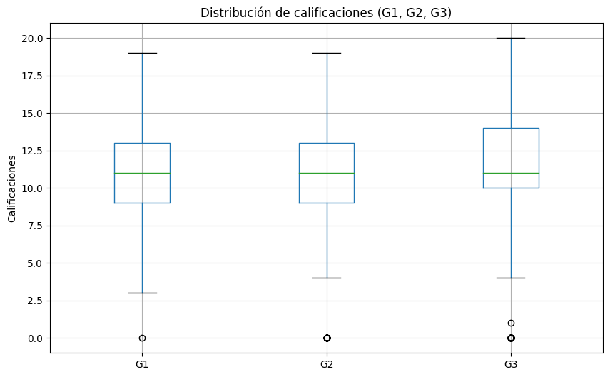

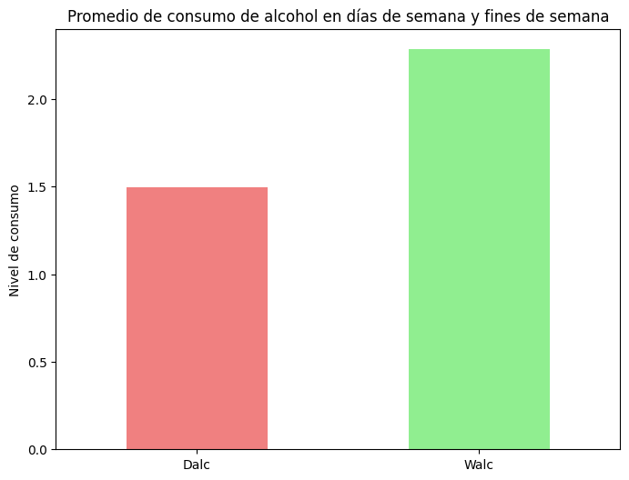

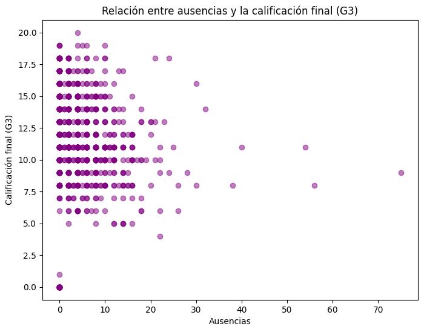

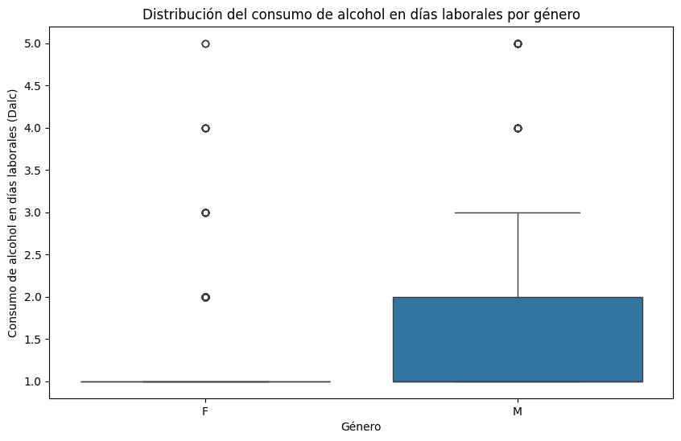

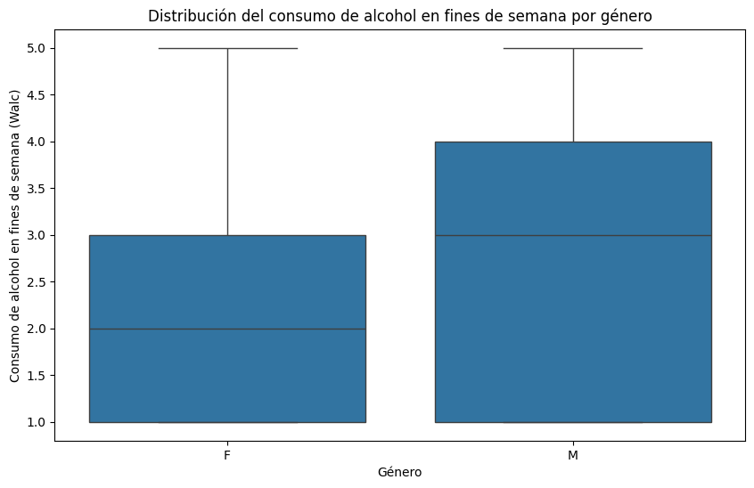

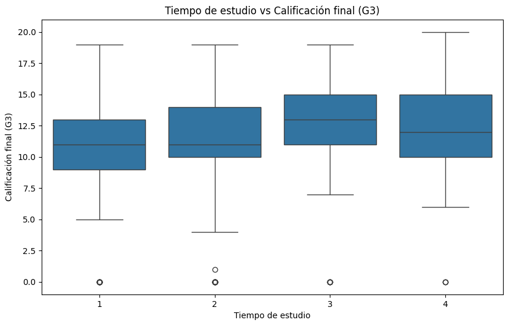

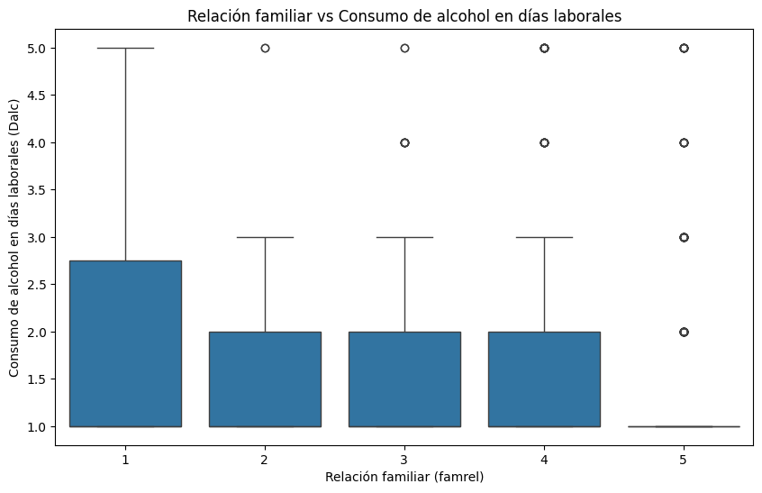

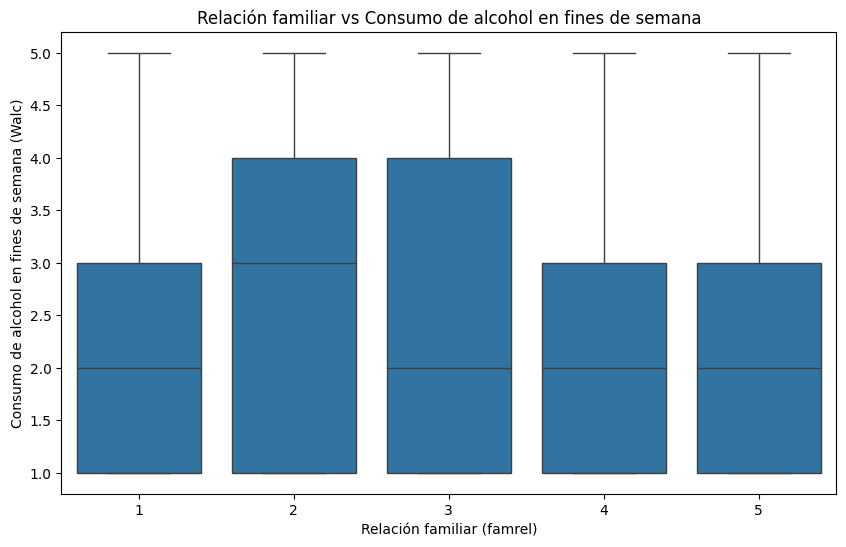

```python
# Gráfico de barras para la distribución de edades
plt.figure(figsize=(8, 6))
data['age'].value_counts().sort_index().plot(kind='bar', color='skyblue')
plt.title('Distribución de edades')
plt.xlabel('Edad')
plt.ylabel('Cantidad de estudiantes')
plt.show()

# Gráfico de cajas para las calificaciones (G1, G2, G3)
plt.figure(figsize=(10, 6))
data[['G1', 'G2', 'G3']].boxplot()
plt.title('Distribución de calificaciones (G1, G2, G3)')
plt.ylabel('Calificaciones')
plt.show()

# Gráfico de barras para el consumo de alcohol en días de semana y fines de semana
plt.figure(figsize=(8, 6))
data[['Dalc', 'Walc']].mean().plot(kind='bar', color=['lightcoral', 'lightgreen'])
plt.title('Promedio de consumo de alcohol en días de semana y fines de semana')
plt.ylabel('Nivel de consumo')
plt.xticks(rotation=0)
plt.show()

# Gráfico de dispersión entre las ausencias y la calificación final G3
plt.figure(figsize=(8, 6))
plt.scatter(data['absences'], data['G3'], color='purple', alpha=0.5)
plt.title('Relación entre ausencias y la calificación final (G3)')
plt.xlabel('Ausencias')
plt.ylabel('Calificación final (G3)')
plt.show()

# Distribution de alcohol por género
plt.figure(figsize=(10, 6))
sns.boxplot(x='sex', y='Dalc', data=data)
plt.title('Distribución del consumo de alcohol en días laborales por género')
plt.xlabel('Género')
plt.ylabel('Consumo de alcohol en días laborales (Dalc)')
plt.show()

plt.figure(figsize=(10, 6))
sns.boxplot(x='sex', y='Walc', data=data)
plt.title('Distribución del consumo de alcohol en fines de semana por género')
plt.xlabel('Género')
plt.ylabel('Consumo de alcohol en fines de semana (Walc)')
plt.show()

# Tiempo de estudio vs calificaciones finales
plt.figure(figsize=(10, 6))
sns.boxplot(x='studytime', y='G3', data=data)
plt.title('Tiempo de estudio vs Calificación final (G3)')
plt.xlabel('Tiempo de estudio')
plt.ylabel('Calificación final (G3)')
plt.show()

# Relación familiar vs Consumo de alcohol en días laborales
plt.figure(figsize=(10, 6))
sns.boxplot(x='famrel', y='Dalc', data=data)
plt.title('Relación familiar vs Consumo de alcohol en días laborales')
plt.xlabel('Relación familiar (famrel)')
plt.ylabel('Consumo de alcohol en días laborales (Dalc)')
plt.show()

plt.figure(figsize=(10, 6))
sns.boxplot(x='famrel', y='Walc', data=data)
plt.title('Relación familiar vs Consumo de alcohol en fines de semana')
plt.xlabel('Relación familiar (famrel)')
plt.ylabel('Consumo de alcohol en fines de semana (Walc)')
plt.show()
```

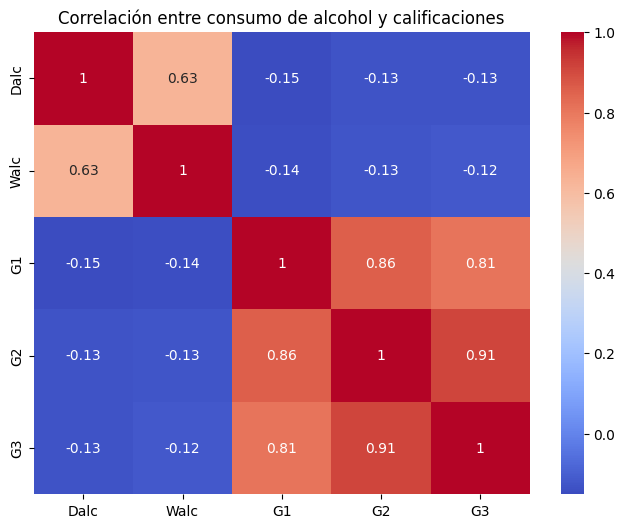

```python
# Verificar correlación entre  entre el consumo de alcohol (Dalc y Walc) y las calificaciones (G1, G2, G3)
correlation_with_grades = data[['Dalc', 'Walc', 'G1', 'G2', 'G3']].corr()

# Mostrar la matriz de correlación
plt.figure(figsize=(8, 6))
sns.heatmap(correlation_with_grades, annot=True, cmap='coolwarm')
plt.title('Correlación entre consumo de alcohol y calificaciones')
plt.show()
```

- Existe una correlación negativa entre el consumo de alcohol durante la semana (Dalc) y las calificaciones finales (G1, G2, G3), lo que indica que a mayor consumo de alcohol durante la semana, las calificaciones tienden a ser más bajas.
- De manera similar, el consumo de alcohol durante el fin de semana (Walc) también tiene una correlación negativa con las calificaciones, aunque es más leve en comparación con el consumo de alcohol en días laborales.

**¿EXISTE ALGÚN TIPO DE CORRELACIÓN CUANDO SE RELACIONA EL GÉNERO?**

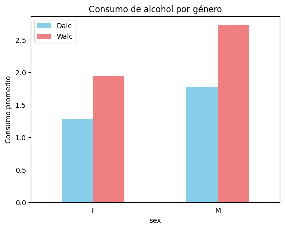

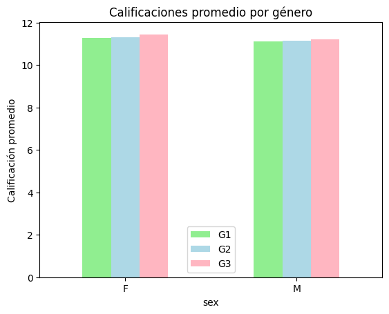

| sex | Dalc | Walc | G1 | G2 | G3 |
| --- | --- | --- | --- | --- | --- |
| F | 1.274112 | 1.944162 | 11.279188 | 11.318105 | 11.448393 |
| M | 1.781457 | 2.728477 | 11.128035 | 11.152318 | 11.203091 |

```python
# Calcular estadísticas descriptivas del consumo de alcohol y las calificaciones agrupadas por género
alcohol_grades_by_gender = data.groupby('sex')[['Dalc', 'Walc', 'G1', 'G2', 'G3']].mean()

# Visualización: Comparación de consumo de alcohol y calificaciones por género
plt.figure(figsize=(10, 6))
alcohol_grades_by_gender[['Dalc', 'Walc']].plot(kind='bar', color=['skyblue', 'lightcoral'])
plt.title('Consumo de alcohol por género')
plt.ylabel('Consumo promedio')
plt.xticks(rotation=0)
plt.show()

plt.figure(figsize=(10, 6))
alcohol_grades_by_gender[['G1', 'G2', 'G3']].plot(kind='bar', color=['lightgreen', 'lightblue', 'lightpink'])
plt.title('Calificaciones promedio por género')
plt.ylabel('Calificación promedio')
plt.xticks(rotation=0)
plt.show()

# Mostrar estadísticas descriptivas
alcohol_grades_by_gender
```

Consumo de alcohol por género:

- Los hombres (M) tienden a tener un consumo de alcohol más alto, tanto en días laborales (Dalc) como en fines de semana (Walc), en comparación con las mujeres (F).

Calificaciones por género:

- Aunque las diferencias son pequeñas, las mujeres (F) tienden a tener calificaciones ligeramente más altas en promedio que los hombres (M) en todas las calificaciones (G1, G2, G3).